# Product SHORT NAME ALGORITHM THEORETICAL BASIS DOCUMENT (ATBD)

## 3.1 Methodology and workflow (mandatory subchapter)

Provides an overview of the product generation, highlighting the workflow, the input datasets, key processes involved, and algorithms used.

Below is a generic example that should be adapted to the specific needs of the product to provide an overview of the production process workflow.

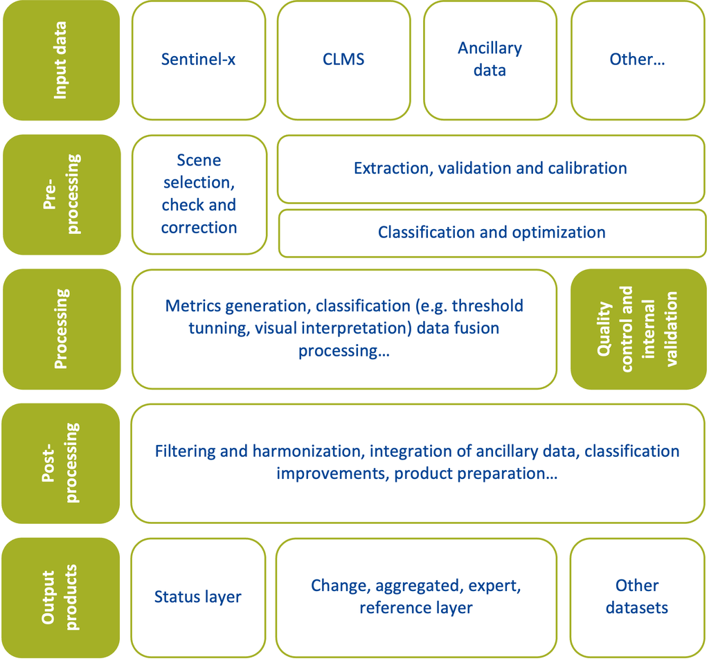

## 3.2 Source data (mandatory subchapter)

Explain which datasets (e.g., Sentinel-x, DEM, or other CLMS products) serve as input for the product. Clarify internal dependencies within the product, such as primary data used to generate secondary outputs. Reference external thematic data where applicable and ensure the workflow diagram illustrates the connections between different datasets.

## 3.3 Pre-processing (mandatory subchapter)

Details the initial steps taken to prepare the data for further processing, including corrections and adjustments to raw data. Sub-chapter structure optional.

### 3.3.1 Pre-processing overview (optional subchapter)

Introduces the pre-processing stage, outlining its purpose and significance in the overall methodology.

### 3.3.2 Input data for pre-processing (optional subchapter)

Lists the various input datasets used in the pre-processing stage.

### 3.3.3 Pre-processing methodology (optional subchapter)

Describes the specific workflow and steps involved in pre-processing the input data, including correction (e.g. atmospheric, topographic, geometric corrections) and cleaning operations within the project activities.

### 3.3.4 Intermediate outputs (optional subchapter)

Specifies the types of output data generated from the pre-processing stage, which will be used in subsequent processing steps.

## 3.4 Processing (mandatory subchapter)

Details the core processing steps that transform pre-processed data into the final products, and the configuration of the tools used for corrections. Product derivation tasks, such as aggregation rules and change layer calculation can be described in this section.

The subchapter structure is optional.

### 3.4.1 Processing overview (optional subchapter)

Summarizes the main goals and components of the processing stage.

### 3.4.2 Input data for processing (optional subchapter)

Identifies the input data required for the processing stage, including pre-processed datasets and additional ancillary data.

### 3.4.3 Processing methodology (optional subchapter)

Outlines the workflow and methods used during the processing stage, detailing each step.

### 3.4.4 Algorithm descriptions (optional subchapter)

Provides detailed descriptions of the algorithms used in the processing stage.

## 3.5 Post-processing (mandatory subchapter)

Presents tasks typically involved in the refinement, validation, and finalization of the datasets such has manual steps, filtering and smoothing, integration of ancillary data, reprojecting, resampling or merging, classification improvements and preparing data for end-users. A subchapter structure as suggested with previous sections may be introduced if necessary.

## 3.6 Output products (mandatory subchapter)

Specifies the types of output products generated (e.g., status layer / change, aggregated, expert, reference layers / and other datasets).

# 4 Quality control and production verification (mandatory subchapter)

Discusses the methods and criteria used to assess the internal validation process (i.e. production verification), the quality and accuracy of the products, ensuring they meet the required standards and specifications.

# 5 Recognized technical issues (mandatory chapter)

Discusses any challenges or limitations of the current methodology, algorithm, input and reference data or technical aspects relevant to the product that might influence its quality, validity or reliability. At the same time, any foreseeable planned developments could be mentioned here.

# 6 Terms of use and product technical support (mandatory chapter)

Presents information on the terms of use, citation guidelines, and technical support for the products.

## 6.1 Terms of use (mandatory subchapter)

Presents information on the legal use of data for added products or derivative works.

Here an example of a standard text.

The Terms of Use for the product(s) described in this document, acknowledge that:

“Free, full and open access to the products and services of the Copernicus Land Monitoring Service is made on the conditions that:

1. When distributing or communicating Copernicus Land Monitoring Service products and services (data, software scripts, web services, user and methodological documentation and similar) to the public, users shall inform the public of the source of these products and services and shall acknowledge that the Copernicus Land Monitoring Service products and services were produced “with funding by the European Union”.
2. Where the Copernicus Land Monitoring Service products and services have been adapted or modified by the user, the user shall clearly state this.
3. Users shall make sure not to convey the impression to the public that the user's activities are officially endorsed by the European Union.

The user has all intellectual property rights to the products he/she has created based on the Copernicus Land Monitoring Service products and services.” [^1]

## 6.2 Citation (mandatory subchapter)

Presents guidelines on how to properly cite and reference the products and services of the CLMS.

Here are examples of standard text to be used according to the situation:

When **planning to publish a publication (scientific, commercial, etc.)**, it should be explicitly mentioned:

When developing a **product or service using the products or services of the Copernicus Land Monitoring Service**, it should explicitly mentioned:

When **redistributing a part of the Copernicus Land Monitoring Service (product, dataset, documentation, picture, web service, etc.)**, it should explicitly mentioned:

## 6.3 Product technical support (mandatory subchapter)

Presents information on the support available for users of the product, including contact details.

Here an example of a standard text.

Product technical support is provided by the product custodian through Copernicus Land Monitoring Service desk[^2]. Product technical support does not include software specific user support or general GIS or remote sensing support.

More information on the products can be found on the Copernicus Land Monitoring Service website (https://land.copernicus.eu/)

# 7 List of abbreviations & acronyms (mandatory chapter)

Lists abbreviations and acronyms used throughout the document.

| Abbreviation | Name | Reference |
| --- | --- | --- |
| ATBD | Algorithm Theoretical Basis Document |  |
| DOI | Digital Object Identifier |  |
| EEA | European Environment Agency | www.eea.europa.eu |
| PUM | Product User Manual |  |

# 8 References (mandatory chapter)

Lists references cited throughout the document.

# 9 Annexes (optional chapter)

Annexes should be kept to a minimum but can be placed as needed to present technical details, data and information repository, resources on product development.

## Footnotes

[^1]: [Copernicus Land Monitoring Service - Data policy](https://land.copernicus.eu/en/data-policy)
[^2]: [Copernicus Land Monitoring Service – Service desk](https://land.copernicus.eu/en/data-policy)